# FDS Final Project: Report #3

Daniel Escoval

27 avril 2024

# Introduction

This is the third report in the series of four reports. This report focus on data analytics using APIs. This report is a good opportunity to train on reading API documentation and getting the data in a meaningful way.

This report will focus on movies analytics from the Move Database, a website that has as a mission to list all the movies created.

They Movie Database describes itself as:

> The Movie Database (TMDB) is a community built movie and TV database. Every piece of data has been added by our amazing community dating back to 2008. TMDB’s strong international focus and breadth of data is largely unmatched and something we’re incredibly proud of. Put simply, we live and breathe community and that’s precisely what makes us different.

In this report we will extract information from their API and get some meaningful analytics.

# The Data

The data comes from the https://www.themoviedb.org/. As the data comes from API calls, we receive it as a JSON scheme. It means the data is not given to us as a table, not in a hierarchical way.

We will mainly focus on the table `movies`, and use the other tables as helpers to make our data more understandable. In the beginning, we will play a bit with other tables to be in shape.

# Analysis

## First tries with the API call

To test the API, we can answer to this question: “What are the highest-grossing dramas from 2010?”

We can find the documentation here: https://developer.themoviedb.org/reference/intro/getting-started and my more personnal data here: https://www.themoviedb.org/settings/api.

The first thing to do is to find the ID of the drama genre.

```r
api_key <- "542bbd1017487a29348fcc6df0e39e66"

genres_url <- httr::GET(stringr::str_glue("https://api.themoviedb.org/3/genre/movie/list?\\
                        api_key={api_key}"))
genres_parsed <- httr::content(genres_url, as = "parsed")

list_genres <- matrix(unlist(genres_parsed[[1]]),ncol=2,byrow=TRUE)

drama_id <- 18
```

The id for the drama genre is: 18.

With this id, we can query all the movies and, directly in the API call, filter by year.

```r
list_drama_movies_2010_get <- httr::GET(stringr::str_glue("https://api.themoviedb.org/3/discover/movie?\\
                                                          include_adult=false&\\
                                                          include_video=false&\\
                                                          language=fr-ch&\\
                                                          page=1&\\
                                                          sort_by=popularity.desc&\\
                                                          with_genres=18&\\
                                                          year=2010&\\
                                                          api_key={api_key}"))

list_drama_movies_2010 <- httr::content(list_drama_movies_2010_get, as = "parsed")

drama_movies_2010 <- tibble()
drama_movies_2010 <- drama_movies_2010 %>%
  mutate(original_title = "NA") %>%
  mutate(french_title = "NA") %>%
  mutate(popularity = "NA")

#Loop through the result to get only the titles of the movies.
for(movie in list_drama_movies_2010){
  if(typeof(movie)=="list"){
    for(characteristic in movie){
      data <- list(
        original_title = characteristic$original_title,
        french_title = characteristic$title
      )
      drama_movies_2010 <- add_row(drama_movies_2010, !!!data)
    }
  }
}

drama_movies_2010
```

| original_title | french_title | popularity |
| --- | --- | --- |
| The Green Mile | La Ligne verte | NA |
| Metropolis | Metropolis | NA |
| Donnie Darko | Donnie Darko | NA |
| The Godfather | Le Parrain | NA |
| The Shawshank Redemption | Les Évadés | NA |
| Inglourious Basterds | Inglourious Basterds | NA |
| Gladiator | Gladiator | NA |
| Fargo | Fargo | NA |
| Heat | Heat | NA |
| The Godfather Part II | Le Parrain, 2e partie | NA |

[output cut: 10 more lines]

Second question: “Have Will Ferrell and Liam Neeson ever been in a movie together?”

First, we need to get actors IDs. We also suggest to take advantage of this query to get all the needed actors for this project and save them in a tibble.

```r
actors <- c("Will%20Ferrell", "Liam%20Neeson", "Tom%20Cruise")

actors_id_tb <- tibble()
actors_id_tb <- actors_id_tb %>%
  mutate(actor_name = "NA") %>%
  mutate(id = "NA")

get_actor_id <- function(url) {
  int_var <- GET(url) %>%
    content(as = "parsed")

  for(actor in int_var){
    if(typeof(actor)=="list"){
      for(characteristics in actor){
        if(typeof(characteristics) == "list"){
          data <- list(
            actor_name = characteristics$name,
            id = as.character(characteristics$id)
          )
          actors_id_tb <- add_row(actors_id_tb, !!!data)
          return( paste(characteristics$name, "ID is", characteristics$id))
        }
      }
    }
  }
}

str_glue("https://api.themoviedb.org/3/search/person?\\
         query={actors}&\\
         include_adult=false&\\
         language=fr-CH&\\
         page=1&\\
         api_key={api_key}")%>%
  map(get_actor_id)
```

```
## [[1]]
## [1] "Will Ferrell ID is 23659"
##
## [[2]]
## [1] "Liam Neeson ID is 3896"
##
## [[3]]
## [1] "Tom Cruise ID is 500"
```

Now I have both IDs, I can search for the films they have in common.

```r
movie_discover_url = "https://api.themoviedb.org/3/discover/movie"
adulte_false_default = "include_adult=false"

join_movies_with_2_actors <- tibble()
join_movies_with_2_actors <- join_movies_with_2_actors %>%
  mutate(original_title = "NA") %>%
  mutate(french_title = "NA")


get_movie <- function(url) {
  int_var <- GET(url) %>%
    content(as = "parsed")

  for(movie in int_var){
    if(typeof(movie)=="list"){
      for(characteristics in movie){
        if(typeof(characteristics) == "list"){
          data <- list(
            original_title = characteristics$original_title,
            french_title = characteristics$title
          )
          join_movies_with_2_actors <- add_row(join_movies_with_2_actors, !!!data)
        }
      }
    }
  }
  return(join_movies_with_2_actors)
}

data_movie <- str_glue("{movie_discover_url}?\\
                       {adulte_false_default}&\\
                       include_video=false&\\
                       language=fr-CH&page=1&\\
                       sort_by=popularity.desc&\\
                       with_cast=3896%2C23659&\\
                       api_key={api_key}") %>%
  map(get_movie)

data_movie
```

```
## [[1]]
## # A tibble: 3 × 2
##   original_title                    french_title
##   <chr>                             <chr>
## 1 Daddy's Home 2                    Very bad dads 2
## 2 The Lego Movie                    La Grande Aventure LEGO
## 3 Anchorman 2: The Legend Continues Légendes vivantes
```

We see that Will Ferell and Liam Neeson were present in the movies in the tibble above.

The last exercise is a combination of the two previous ones.

We want to know if Tom Cruise already played in a kid’s movie.

First note, that there is no kid’s movie genre, but we will agree for this work that “kid’s movie” is a “familial” movie genre.

```r
movie_discover_url = "https://api.themoviedb.org/3/discover/movie"
adulte_false_default = "include_adult=false"

kids_movies_tom_cruise <- tibble()
kids_movies_tom_cruise <- kids_movies_tom_cruise %>%
  mutate(original_title = "NA") %>%
  mutate(french_title = "NA")


get_movie_kids_tm_cruise <- function(url) {
  int_var <- GET(url) %>%
    content(as = "parsed")

  for(movie in int_var){
    if(typeof(movie)=="list"){
      for(characteristics in movie){
        if(typeof(characteristics) == "list"){
          data <- list(
            original_title = characteristics$original_title,
            french_title = characteristics$title
          )
          kids_movies_tom_cruise <- add_row(kids_movies_tom_cruise, !!!data)
        }
      }
    }
  }
  return(kids_movies_tom_cruise)
}

data_movie_kids_tom_cruise <- str_glue("{movie_discover_url}?\\
                                       {adulte_false_default}&\\
                                       include_video=false&\\
                                       language=fr-CH&\\
                                       page=1&sort_by=popularity.desc&\\
                                       with_cast=500&\\
                                       with_genres=10751&\\
                                       api_key={api_key}") %>%
  map(get_movie_kids_tm_cruise)

data_movie_kids_tom_cruise
```

```
## [[1]]
## # A tibble: 0 × 2
## # ℹ 2 variables: original_title <chr>, french_title <chr>
```

It seems that Tom Cruise never acted in a Family movie.

## Disney and Pixar analysis

Let’s have the ID of the movie company: Pixar.

Here is Pixar ID: 3

```r
number_pages <- c(1:7)

get_movie <- function(url){
  result <- GET(url) %>%
    content(as = "parsed")
  return(result$results)
}

pixar_search <- str_glue("https://api.themoviedb.org/3/discover/movie?\\
                          include_adult=false&\\
                          include_video=false&\\
                          language=fr-CH&\\
                          sort_by=popularity.desc&\\
                          with_companies=3&\\
                          api_key={api_key}&\\
                          page={number_pages}") %>%
  map(get_movie) %>%
  purrr::flatten() %>%
  map_df(magrittr::extract, c("id","original_title","title","vote_average","vote_count","release_date"))

pixar_search
```

| id | original_title | title | vote_average | vote_count | release_date |
| --- | --- | --- | --- | --- | --- |
| 1022789 | Inside Out 2 | Vice-versa 2 | 0.000 | 0 | 2024-06-12 |
| 150540 | Inside Out | Vice-versa | 7.915 | 20254 | 2015-06-09 |
| 976573 | Elemental | Élémentaire | 7.657 | 3974 | 2023-06-14 |
| 862 | Toy Story | Toy Story | 7.972 | 17797 | 1995-10-30 |
| 14160 | Up | Là-haut | 7.957 | 19566 | 2009-05-28 |
| 508947 | Turning Red | Alerte rouge | 7.392 | 4907 | 2022-03-10 |
| 585 | Monsters, Inc. | Monstres & Cie | 7.842 | 17838 | 2001-11-01 |
| 354912 | Coco | Coco | 8.213 | 18731 | 2017-10-27 |
| 2062 | Ratatouille | Ratatouille | 7.819 | 16411 | 2007-06-28 |
| 301528 | Toy Story 4 | Toy Story 4 | 7.501 | 9432 | 2019-06-19 |

[output cut: 122 more lines]

You may know that Pixar was acquired by Disney in 2006 after they had already been collaborating on films for more than a decade. For the last part of the report, we will look into whether this was a smart strategic decision by Disney by comparing the popularity of both Disney and Pixar films that came out from 2006 onwards.

Let’s first get Disney’s ID:

```r
result_disney_id <- str_glue("https://api.themoviedb.org/3/search/company?\\
                             query=Walt%20Disney%20Pictures&\\
                             page=1&\\
                             api_key={api_key}") %>%
  GET()%>%
  content(as = "parsed")

for(company in result_disney_id$results){
  if(company$name == "Walt Disney Pictures"){
    disney_id <- company$id
  }
}
```

Here is Disney ID: 2

```r
number_pages <- c(1:26)

disney_search <- str_glue("https://api.themoviedb.org/3/discover/movie?\\
                          include_adult=false&\\
                          include_video=false&\\
                          language=fr-CH&\\
                          sort_by=popularity.desc&\\
                          with_companies=2&\\
                          api_key={api_key}&\\
                          page={number_pages}") %>%
  map(get_movie) %>%
  purrr::flatten() %>%
  map_df(magrittr::extract, c("id","original_title","title","vote_average","vote_count", "release_date"))
```

Now we have our data for Disney movies and the one for Pixar movies. Let’s now compare both tibbles.

```r
pixar_movies_from_2006 <- pixar_search %>%
  mutate(release_date = as.Date(release_date)) %>%
  filter(release_date > "2006-01-01") %>%
  select(-release_date) %>%
  mutate(company = "Pixar")

disney_movies_from_2006 <- disney_search %>%
  mutate(release_date = as.Date(release_date)) %>%
  filter(release_date > "2006-01-01") %>%
  select(-release_date) %>%
  mutate(company = "Disney")

comparison_tibble <- rbind(pixar_movies_from_2006, disney_movies_from_2006)
comparison_tibble
```

| id | original_title | title | vote_average | vote_count | company |
| --- | --- | --- | --- | --- | --- |
| 1022789 | Inside Out 2 | Vice-versa 2 | 0.000 | 0 | Pixar |
| 150540 | Inside Out | Vice-versa | 7.915 | 20254 | Pixar |
| 976573 | Elemental | Élémentaire | 7.657 | 3974 | Pixar |
| 14160 | Up | Là-haut | 7.957 | 19566 | Pixar |
| 508947 | Turning Red | Alerte rouge | 7.392 | 4907 | Pixar |
| 354912 | Coco | Coco | 8.213 | 18731 | Pixar |
| 2062 | Ratatouille | Ratatouille | 7.819 | 16411 | Pixar |
| 301528 | Toy Story 4 | Toy Story 4 | 7.501 | 9432 | Pixar |
| 10681 | WALL·E | WALL·E | 8.088 | 18144 | Pixar |
| 260514 | Cars 3 | Cars 3 | 6.850 | 5528 | Pixar |

[output cut: 311 more lines]

Now we have a tibble with both data we can play with.

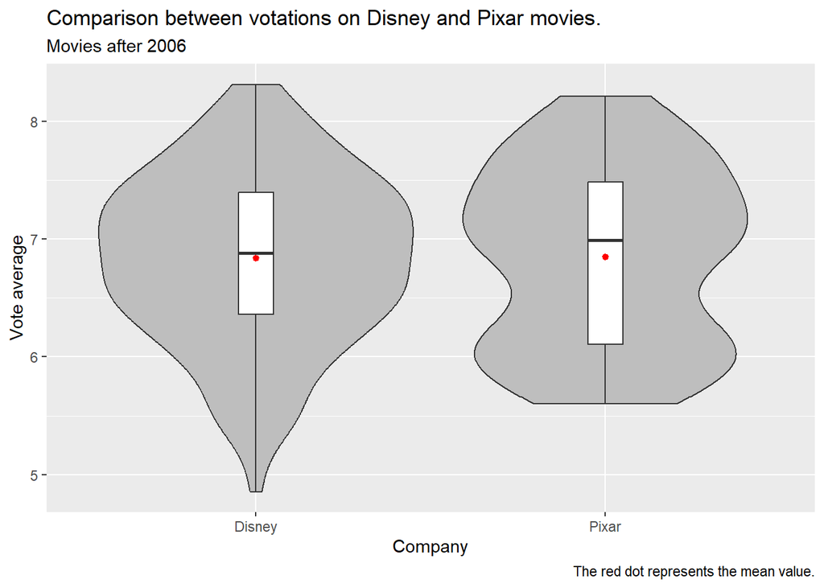

```r
comparison_tibble_clean <- comparison_tibble %>%
  mutate(vote_count = as.numeric(vote_count)) %>%
  mutate(vote_average = as.double(vote_average)) %>%
  filter(vote_count > 50)

comparison_tibble_clean %>%
  ggplot(aes(x=company, y=vote_average)) +
    geom_violin(fill="gray")+
    geom_boxplot(width=0.1) +
    labs(
      title="Comparison between votations on Disney and Pixar movies.",
      subtitle="Movies after 2006",
      caption="The red dot represents the mean value.",
      x="Company",
      y="Vote average"
      )+
    stat_summary(fun="mean", colour = "red", size = 0.25)
```

```r
comparison_tibble_clean %>%
  group_by(company) %>%
  summarise(
    group_size = n(),
    median = median(vote_average),
    average = mean(vote_average),
    standard_deviation = sd(vote_average),
    minimum = min(vote_average),
    maximum = max(vote_average)
  )
```

| company | group_size | median | average | standard_deviation | minimum | maximum |
| --- | --- | --- | --- | --- | --- | --- |
| Disney | 176 | 6.8825 | 6.837222 | 0.7155909 | 4.855 | 8.313 |
| Pixar | 87 | 6.9890 | 6.851138 | 0.7516866 | 5.600 | 8.213 |

### Conclusion of Disney - Pixar comparison

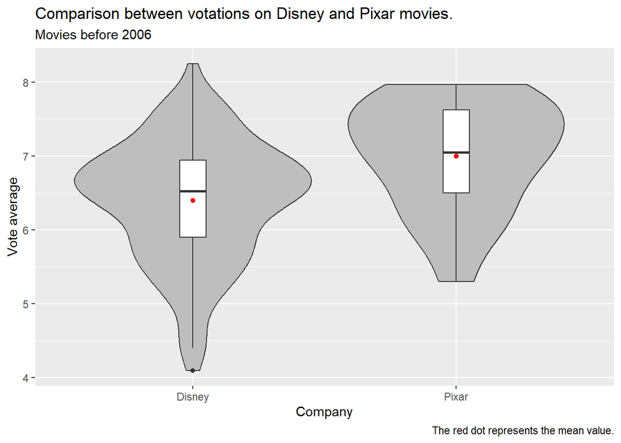

```r
disney_before_2006 <- disney_search %>%
  mutate(release_date = as.Date(release_date)) %>%
  filter(release_date < "2006-01-01") %>%
  select(-release_date) %>%
  mutate(company = "Disney")

pixar_movies_before_2006 <- pixar_search %>%
  mutate(release_date = as.Date(release_date)) %>%
  filter(release_date < "2006-01-01") %>%
  select(-release_date) %>%
  mutate(company = "Pixar")

comparison_tibble_before_2006 <- rbind(pixar_movies_before_2006, disney_before_2006)

comparison_tibble_before_2006_clean <- comparison_tibble_before_2006 %>%
  mutate(vote_count = as.numeric(vote_count)) %>%
  mutate(vote_average = as.double(vote_average)) %>%
  filter(vote_count > 50)

comparison_tibble_before_2006_clean %>%
  ggplot(aes(x=company, y=vote_average)) +
    geom_violin(fill="gray")+
    geom_boxplot(width=0.1) +
    labs(
      title="Comparison between votations on Disney and Pixar movies.",
      subtitle="Movies before 2006",
      caption="The red dot represents the mean value.",
      x="Company",
      y="Vote average"
      )+
    stat_summary(fun="mean", colour = "red", size = 0.25)
```

```r
comparison_tibble_clean %>%
  group_by(company) %>%
  summarise(
    group_size = n(),
    median = median(vote_average),
    average = mean(vote_average),
    standard_deviation = sd(vote_average),
    minimum = min(vote_average),
    maximum = max(vote_average)
  )
```

[output not shown]

# Conclusion

An API is a very powerful tool to get access to data. In this report, we saw that the acquisitionof Pixar by Disney seems not ahve conclude in a better quality of movies. The increase of votes seems to follow a certain curve and population aging. Also, we see that Pixar still has less movies that Disney, which maybe shows that Pixar tends to try to focus on quality and Disney in quantity. But these trends are not really visible.

# Sources

## Help for analysis

https://www.themoviedb.org/ https://www.lemondeinformatique.fr/actualites/lire-focus-sur-json-le-format-star-des-echanges-de-donnees-76951.html